# Annual Fund $10K Model Data Exploration

### Giving velocity

I’ll use the [Blackbaud](https://www.kb.blackbaud.com/articles/Article/57194) definition, which compares last to three previous years of giving.

$$V_3 = \left\{
\begin{array}{l l}
\frac{FY_t}{\frac{1}{3} \sum_{i=1}^{3}FY_{t-i}} \text{ when } \sum_{i=1}^{3}FY_{t-i} > 0 \\
1 \text{ otherwise}
\end{array}
\right.$$

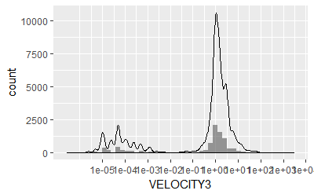

```r
full.data %>% mutate(
    denom = 1/3 * (CASH_PFY2 + CASH_PFY3 + CASH_PFY4)
  , VELOCITY3 = CASH_PFY1 / ifelse(denom == 0, max(CASH_PFY1, 1E-99), denom)
) %>% histogrammer('VELOCITY3', data = ., m = 50) +
  scale_x_log10(breaks = 10^(-5:5))
```

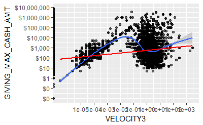

```r
full.data %>% mutate(
    denom = 1/3 * (CASH_PFY2 + CASH_PFY3 + CASH_PFY4)
  , VELOCITY3 = CASH_PFY1 / ifelse(denom == 0, max(CASH_PFY1, 1E-99), denom)
) %>% filter(GIVING_MAX_CASH_AMT > 0) %>%
  scatterplotter('VELOCITY3', data = .) +
    scale_x_log10(breaks = 10^(-5:5))
```

Well, that’s unexpected. There are likely interactions with age and Reunion cycle. Evidence for 4-6 clusters.

- Nondonors during the entire period
- V3 = -Inf (?)
- 1E-8 < V3 < 1E-2
- 1E-2 < V3 < 1
- V3 = 1 (?)
- V3 > 1

```r
full.data %>% mutate(
    denom = 1/3 * (CASH_PFY2 + CASH_PFY3 + CASH_PFY4)
  , VELOCITY3 = CASH_PFY1 / ifelse(denom == 0, max(CASH_PFY1, 1E-99), denom)
  , VELOCITY_DISCR = case_when(
      CASH_PFY1 == 0 & denom == 0 ~ 'A. Non'
    , VELOCITY3 < 1E-8 ~ 'B. Way down'
    , VELOCITY3 < 1E-2 ~ 'C. Moderate down'
    , VELOCITY3 < 1 ~ 'D. Slight down'
    , VELOCITY3 == 1 ~ 'E. Unchanged'
    , VELOCITY3 > 1 ~ 'F. Up'
  )
) %>% select(VELOCITY_DISCR) %>% table()
```

```
.
          A. Non      B. Way down C. Moderate down   D. Slight down     E. Unchanged
           76476             7843             1950             1533             1156
           F. Up
            4269
```

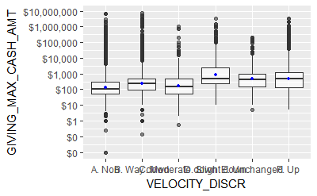

```r
full.data %>% mutate(
    denom = 1/3 * (CASH_PFY2 + CASH_PFY3 + CASH_PFY4)
  , VELOCITY3 = CASH_PFY1 / ifelse(denom == 0, max(CASH_PFY1, 1E-99), denom)
  , VELOCITY_DISCR = case_when(
      CASH_PFY1 == 0 & denom == 0 ~ 'A. Non'
    , VELOCITY3 < 1E-8 ~ 'B. Way down'
    , VELOCITY3 < 1E-2 ~ 'C. Moderate down'
    , VELOCITY3 < 1 ~ 'D. Slight down'
    , VELOCITY3 == 1 ~ 'E. Unchanged'
    , VELOCITY3 > 1 ~ 'F. Up'
  )
) %>% boxplotter('VELOCITY_DISCR', data = .) +
  stat_summary(fun.y = mean, geom = 'point', size = 1, color = 'blue')
```

Not super-clean but might as well see if it has any predictive power. **Include `VELOCITY3`.** **Include `VELOCITY_DISCR` as a factor.**

Alternate velocity definition: take *difference* between last year and average giving, rather than the ratio?

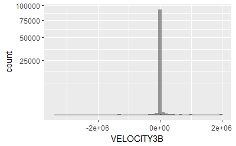

```r
full.data <- full.data %>% mutate(
  avg = 1/3 * (CASH_PFY2 + CASH_PFY3 + CASH_PFY4)
  , VELOCITY3B = CASH_PFY1 - avg
)
full.data %>%
  histogrammer('VELOCITY3B', data = ., m = 50) +
  scale_y_sqrt()
```

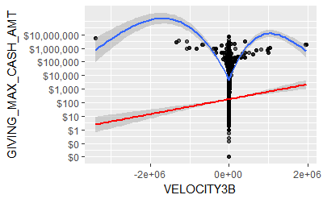

```r
full.data %>% filter(GIVING_MAX_CASH_AMT > 0) %>%
  scatterplotter('VELOCITY3B', data = .)
```

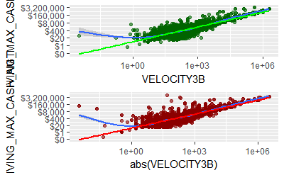

```r
grid.arrange(
  full.data %>% filter(GIVING_MAX_CASH_AMT > 0, VELOCITY3B > 0) %>%
    ggplot(aes(x = VELOCITY3B, y = GIVING_MAX_CASH_AMT)) +
    geom_point(alpha = .6, color = 'darkgreen') +
    geom_smooth() +
    geom_smooth(method = 'lm', color = 'green') +
    scale_y_log10(breaks = 20^(-2:7), labels = scales::dollar) +
    scale_x_log10()
, full.data %>% filter(GIVING_MAX_CASH_AMT > 0, VELOCITY3B < 0) %>%
    ggplot(aes(x = abs(VELOCITY3B), y = GIVING_MAX_CASH_AMT)) +
    geom_point(alpha = .6, color = 'darkred') +
    geom_smooth() +
    geom_smooth(method = 'lm', color = 'red') +
    scale_y_log10(breaks = 20^(-2:7), labels = scales::dollar) +
    scale_x_log10()
)
```

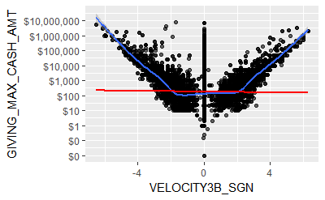

```r
# Log10 scale preserving sign
full.data %>% mutate(VELOCITY3B_SGN = log10(abs(VELOCITY3B) + 1) * sign(VELOCITY3B)) %>%
  scatterplotter('VELOCITY3B_SGN', data = .)
```

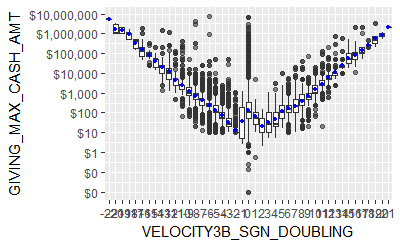

```r
full.data %>% mutate(VELOCITY3B_SGN_DOUBLING = {log2(abs(VELOCITY3B) + 1) * sign(VELOCITY3B)} %>%
                       round() %>% factor()) %>%
  boxplotter('VELOCITY3B_SGN_DOUBLING', data = .) +
  stat_summary(fun.y = mean, geom = 'point', size = 1, color = 'blue')
```

Wonder why Blackbaud doesn’t use this? So much cleaner. **Include `VELOCITY3B_SGN` as numeric.** Consider truncating to e.g. $\pm 4$

### Age imputation

Issue: various entities are either missing age or have something unreasonable (2 years old when receiving their MBA).

```r
full.data %>% select(DOB) %>% is.na() %>% sum()
```

```
[1] 27237
```

Over 27,000 unknown age.

```r
full.data %>% mutate(under_21 = FIRST_KSM_YEAR - year(DOB) < 21) %>%
  filter(year(DOB) > 1000 & FIRST_KSM_YEAR > 1000) %>% select(under_21) %>%
  unlist() %>% na.omit() %>% sum()
```

```
[1] 214
```

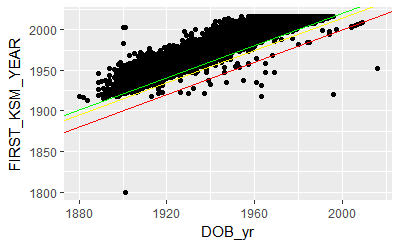

```r
full.data %>% mutate(DOB_yr = year(DOB)) %>% filter(DOB_yr > 1000 & FIRST_KSM_YEAR > 1000) %>%
  ggplot(aes(x = DOB_yr, y = FIRST_KSM_YEAR)) +
  geom_point() +
  geom_abline(slope = 1, intercept = 21, color = 'green') +
  geom_abline(slope = 1, intercept = 15, color = 'yellow') +
  geom_abline(slope = 1, intercept = 0, color = 'red')
```

Between green and yellow lines are supposedly people < 21 when graduating; yellow and red are people < 15; under red line means graduation year is before they were born.

Two possibilities: age imputation, or use a comparable but more accurate metric.

Proposal: record year, defined as `FIRST_KSM_YEAR` for graduates, first year of giving for nongraduates if available, else record creation date. All grad years < 1908 can be set to 1908 (founding year).

# Data file cleanup goals

- R script to clean data file for processing
- Written as a function taking data file path as an argument

This is implemented in parse_data.R.